# Tarea Ridge,Lasso & Elastic-Net

```r
load("C:/Users/Alex/Downloads/Variables 7.RData")
```

## Introducción

BASE DE DATOS: Credit_risk_dataset

FUENTE: Kaggle

Integrantes : Alejandro Cañadas, Antonio Morcillo , Geovanny Jaramillo

La base de datos escogida nos proporciona informacion financiera ,demográfica y específica acerca de la aprobación de préstamos. Diseñada con variables influyentes en el analisis de riesgo de crédito, nos permite hacer estudios, predicciones y en este caso un analisis de clasificación binaria sobre nuestra variable objetivo.

Con regresión penalizada veremos cual es el modelo que mejor clasifica y predice nuestra variable target, que será el estado del préstamo, si bien ha sido aprobado por la entidad financiera o rechazado  
Variable target: Loan_status (1 approved, 0 rejected).

## Estadísticos descriptivos

Objetivo: Predecir estado de crédito a través de la evaluación de 3 modelos de regresión penalizada

Tipo de problema: Supervisado, clasificación

Variable target: Estado del préstamo (Loan_status)

obsevaciones: 32.581

## Análisis exploratorio

```r
library(tidymodels)
library(dplyr)
library(rsample)
library(xgboost)
library(parallel)
library(doParallel)
library(yardstick)
library(vip)
```

```r
# Código en el chunk
dim(loan_data)      # Dimensiones
```

```
[1] 32581    12
```

```r
names(loan_data)    # Nombres de las columnas
```

```
 [1] "person_age"                 "person_income"
 [3] "person_home_ownership"      "person_emp_length"
 [5] "loan_intent"                "loan_grade"
 [7] "loan_amnt"                  "loan_int_rate"
 [9] "loan_status"                "loan_percent_income"
[11] "cb_person_default_on_file"  "cb_person_cred_hist_length"
```

```r
str(loan_data)      # Estructura de los datos
```

```
'data.frame':   32581 obs. of  12 variables:
 $ person_age                : int  22 21 25 23 24 21 26 24 24 21 ...
 $ person_income             : int  59000 9600 9600 65500 54400 9900 77100 78956 83000 10000 ...
 $ person_home_ownership     : Factor w/ 4 levels "MORTGAGE","OTHER",..: 4 3 1 4 4 3 4 4 4 3 ...
 $ person_emp_length         : num  123 5 1 4 8 2 8 5 8 6 ...
 $ loan_intent               : Factor w/ 6 levels "DEBTCONSOLIDATION",..: 5 2 4 4 4 6 2 4 5 6 ...
 $ loan_grade                : Ord.factor w/ 7 levels "A"<"B"<"C"<"D"<..: 4 2 3 3 3 1 2 2 1 4 ...
 $ loan_amnt                 : int  35000 1000 5500 35000 35000 2500 35000 35000 35000 1600 ...
 $ loan_int_rate             : num  16 11.1 12.9 15.2 14.3 ...
 $ loan_status               : Factor w/ 2 levels "0","1": 2 1 2 2 2 2 2 2 2 2 ...
 $ loan_percent_income       : num  0.59 0.1 0.57 0.53 0.55 0.25 0.45 0.44 0.42 0.16 ...
 $ cb_person_default_on_file : Factor w/ 2 levels "N","Y": 2 1 1 1 2 1 1 1 1 1 ...
 $ cb_person_cred_hist_length: int  3 2 3 2 4 2 3 4 2 3 ...
```

```r
summary(loan_data)
```

```
   person_age     person_income     person_home_ownership person_emp_length
 Min.   : 20.00   Min.   :   4000   MORTGAGE:13444        Min.   :  0.00
 1st Qu.: 23.00   1st Qu.:  38500   OTHER   :  107        1st Qu.:  2.00
 Median : 26.00   Median :  55000   OWN     : 2584        Median :  4.00
 Mean   : 27.73   Mean   :  66075   RENT    :16446        Mean   :  4.79
 3rd Qu.: 30.00   3rd Qu.:  79200                         3rd Qu.:  7.00
 Max.   :144.00   Max.   :6000000                         Max.   :123.00
                                                          NA's   :895
            loan_intent   loan_grade   loan_amnt     loan_int_rate
 DEBTCONSOLIDATION:5212   A:10777    Min.   :  500   Min.   : 5.42
 EDUCATION        :6453   B:10451    1st Qu.: 5000   1st Qu.: 7.90
 HOMEIMPROVEMENT  :3605   C: 6458    Median : 8000   Median :10.99
 MEDICAL          :6071   D: 3626    Mean   : 9589   Mean   :11.01
 PERSONAL         :5521   E:  964    3rd Qu.:12200   3rd Qu.:13.47
 VENTURE          :5719   F:  241    Max.   :35000   Max.   :23.22
                          G:   64                    NA's   :3116
 loan_status loan_percent_income cb_person_default_on_file
 0:25473     Min.   :0.0000      N:26836
 1: 7108     1st Qu.:0.0900      Y: 5745
             Median :0.1500
             Mean   :0.1702
             3rd Qu.:0.2300
             Max.   :0.8300

 cb_person_cred_hist_length
 Min.   : 2.000
 1st Qu.: 3.000
 Median : 4.000
 Mean   : 5.804
 3rd Qu.: 8.000
 Max.   :30.000
```

Tenemos todo tipo de features en esta base de datos tanto numericas como factores, ordinales y nominales que tendremos que tratar para poder incluirlas

```r
str(loan_data)
```

```
'data.frame':   32581 obs. of  12 variables:
 $ person_age                : int  22 21 25 23 24 21 26 24 24 21 ...
 $ person_income             : int  59000 9600 9600 65500 54400 9900 77100 78956 83000 10000 ...
 $ person_home_ownership     : Factor w/ 4 levels "MORTGAGE","OTHER",..: 4 3 1 4 4 3 4 4 4 3 ...
 $ person_emp_length         : num  123 5 1 4 8 2 8 5 8 6 ...
 $ loan_intent               : Factor w/ 6 levels "DEBTCONSOLIDATION",..: 5 2 4 4 4 6 2 4 5 6 ...
 $ loan_grade                : Ord.factor w/ 7 levels "A"<"B"<"C"<"D"<..: 4 2 3 3 3 1 2 2 1 4 ...
 $ loan_amnt                 : int  35000 1000 5500 35000 35000 2500 35000 35000 35000 1600 ...
 $ loan_int_rate             : num  16 11.1 12.9 15.2 14.3 ...
 $ loan_status               : Factor w/ 2 levels "0","1": 2 1 2 2 2 2 2 2 2 2 ...
 $ loan_percent_income       : num  0.59 0.1 0.57 0.53 0.55 0.25 0.45 0.44 0.42 0.16 ...
 $ cb_person_default_on_file : Factor w/ 2 levels "N","Y": 2 1 1 1 2 1 1 1 1 1 ...
 $ cb_person_cred_hist_length: int  3 2 3 2 4 2 3 4 2 3 ...
```

La distribución es claramente asimétrica hacia la derecha. Aunque la mediana este por debajo de los 10.000$, hay muchos outliers a la derecha

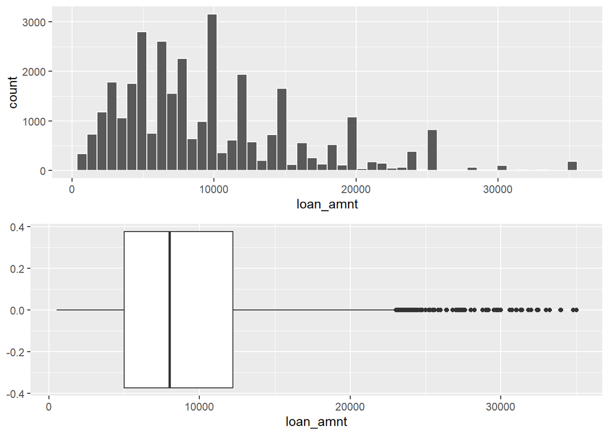

```r
plot1 <- ggplot(loan_data, aes(x = loan_amnt)) +
  geom_histogram(bins=50, col= "White")
plot2 <- ggplot(loan_data, aes(y = loan_amnt)) +
  geom_boxplot()+coord_flip()
gridExtra::grid.arrange(plot1, plot2)
```

Tras aplicar logaritmos vemos que la transformación es demasiado fuerte

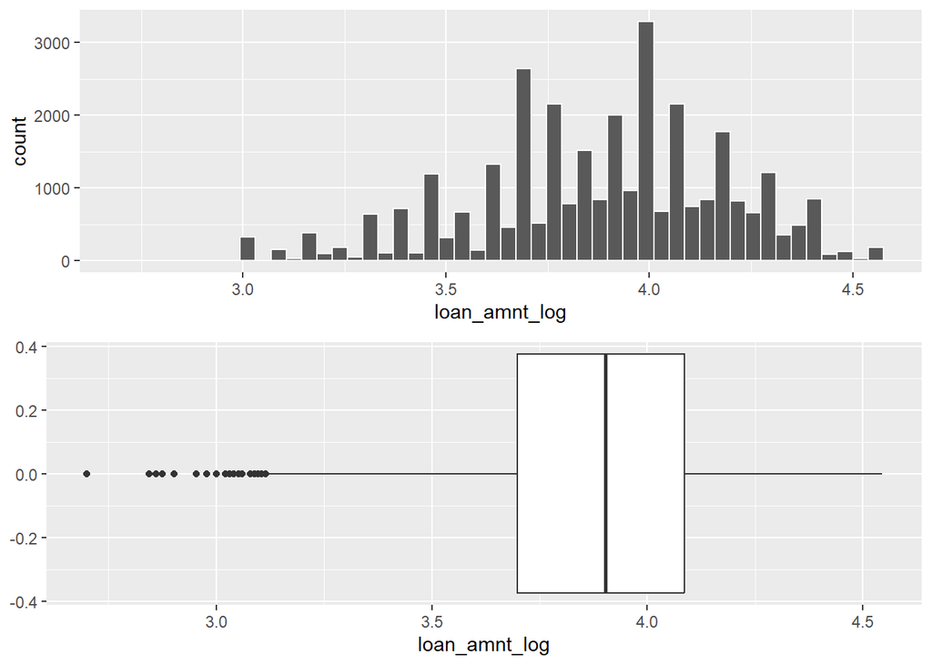

```r
loan_data$loan_amnt_log <- log10(loan_data$loan_amnt)

plot1 <- ggplot(loan_data, aes(x = loan_amnt_log)) +
  geom_histogram(bins=50, col= "White")
plot2 <- ggplot(loan_data, aes(y = loan_amnt_log)) +
  geom_boxplot()+coord_flip()
gridExtra::grid.arrange(plot1, plot2)
```

Con la raís cuadráda la transformación sigue siendo demasiado fuerte asi que con la raíz cúbica la distribución queda más simetrica

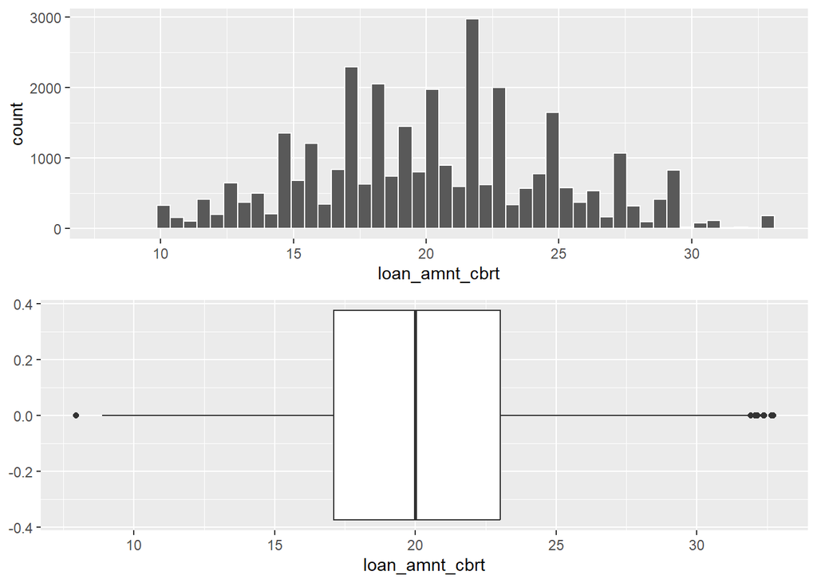

```r
loan_data$loan_amnt_cbrt <- loan_data$loan_amnt^(1/3)

plot1 <- ggplot(loan_data, aes(x = loan_amnt_cbrt)) +
  geom_histogram(bins=50, col= "White")
plot2 <- ggplot(loan_data, aes(y = loan_amnt_cbrt)) +
  geom_boxplot()+coord_flip()
gridExtra::grid.arrange(plot1, plot2)
```

Analisis de la variable loan_status. La mayoria de prestamos son rechazados

```r
loan_data |>
  count(loan_status) |>
  mutate(percentage = n / sum(n) * 100)
```

```
  loan_status     n percentage
1           0 25473    78.1836
2           1  7108    21.8164
```

Ahora agrupado por la intención del proposito de préstamo:

```r
loan_data_summary_intent <- loan_data |>
  group_by(loan_intent) |>
  summarise(
    total_loans = n(),
    approved_loans_intent = sum(loan_status == 1),
    rejected_loans_intent = sum(loan_status == 0),
    approval_rate_intent = mean(loan_status == 1),
    rejection_rate_intent = mean(loan_status == 0)
  );loan_data_summary_intent
```

```
# A tibble: 6 × 6
  loan_intent       total_loans approved_loans_intent rejected_loans_intent
  <fct>                   <int>                 <int>                 <int>
1 DEBTCONSOLIDATION        5212                  1490                  3722
2 EDUCATION                6453                  1111                  5342
3 HOMEIMPROVEMENT          3605                   941                  2664
4 MEDICAL                  6071                  1621                  4450
5 PERSONAL                 5521                  1098                  4423
6 VENTURE                  5719                   847                  4872
# ℹ 2 more variables: approval_rate_intent <dbl>, rejection_rate_intent <dbl>
```

Tratamiento de variables y recipe

Comprobamos si hay valores vacios . Hay valores nulos solo en dos columnas, ambas numéricas.

Tras hacer la transformación comprobamos que no haya valores nulos

```r
# Eliminar valores nulos
sum(is.na(loan_data))
```

```
[1] 4011
```

```r
colSums(is.na(loan_data)) #Suma de valores nulos
```

```
                person_age              person_income
                         0                          0
     person_home_ownership          person_emp_length
                         0                        895
               loan_intent                 loan_grade
                         0                          0
                 loan_amnt              loan_int_rate
                         0                       3116
               loan_status        loan_percent_income
                         0                          0
 cb_person_default_on_file cb_person_cred_hist_length
                         0                          0
             loan_amnt_log             loan_amnt_cbrt
                         0                          0
```

```r
loan_data[loan_data == ""] <- NA

sum(is.na(loan_data$person_emp_length)) #Comprobación
```

```
[1] 895
```

```r
sum(is.na(loan_data$loan_int_rate))
```

```
[1] 3116
```

Convertir variables categóricas en factores

```r
nominal_features <- c('person_home_ownership','cb_person_default_on_file','loan_intent')
ordinal_features <- c('loan_grade')
numeric_predictors <- loan_data |> select(where(is.numeric))

loan_data$person_home_ownership <- as.factor(loan_data$person_home_ownership)
loan_data$cb_person_default_on_file <- as.factor(loan_data$cb_person_default_on_file)
loan_data$loan_intent <- as.factor(loan_data$loan_intent)
loan_data$loan_status <- as.factor(loan_data$loan_status)
```

Loan_grade a factor ordenado

```r
loan_data <- loan_data|>
  mutate(loan_grade = factor(loan_grade, levels =c('A','B','C','D','E','F','G'),ordered = TRUE))
```

Pasamos a hacer el data splitting en training y test y fijamos semilla. Dedicamos un 70% de los datos a training y 30% a test para evitar el overfitting.

```r
library(rsample)
set.seed(123)
loan_split <- initial_split(loan_data, prop = 0.7)
loan_train <- training(loan_split)
loan_test <- testing(loan_split)
```

## Paso 2 Recipe

Elaboramos la recipe con los pasos del data engineering

```r
loan_recipe <- recipe(loan_status~.,data=loan_data)|>
  step_nzv(all_predictors())|>
  step_naomit(all_predictors()) |>
  step_integer(all_ordered_predictors()) |>
  step_other(all_nominal_predictors(), threshold = 0.01) |>
  step_impute_knn(all_predictors(), neighbors = 5) |>
  step_ordinalscore(all_ordered_predictors())|>
  #Como no tenemos ninguna variables con demasiados niveles no usamos step_other para agrupar
  step_dummy(all_nominal_predictors(),one_hot=FALSE)|>
  step_YeoJohnson(all_numeric_predictors())|>
  step_normalize(all_numeric_predictors())
#al no haber altas correlaciones no aplicamos PCA
```

Y aplicamos receta

```r
loan_recipe_prepared <- prep(loan_recipe, training = loan_data)
transformed_data <- bake(loan_recipe_prepared, new_data = NULL)
```

Para asegurar que ha funcionado vemos los datos normalizados y que ahora son numericos todos los features:

```r
head (transformed_data)
```

```
# A tibble: 6 × 20
  person_age person_income person_emp_length loan_grade loan_amnt loan_int_rate
       <dbl>         <dbl>             <dbl>      <dbl>     <dbl>         <dbl>
1     -1.34         0.108             6.79       1.38       2.54         1.46
2     -1.81        -3.39              0.312      0.0373    -2.41         0.0985
3     -0.289       -3.39             -1.03       0.826     -0.552        0.610
4     -0.938        0.294             0.0615     0.826      2.54         1.26
5     -0.591       -0.0374            0.913      0.826      2.54         1.00
6     -1.81        -3.33             -0.579     -1.24      -1.50        -1.25
# ℹ 14 more variables: loan_percent_income <dbl>,
#   cb_person_cred_hist_length <dbl>, loan_amnt_log <dbl>,
#   loan_amnt_cbrt <dbl>, loan_status <fct>, person_home_ownership_OWN <dbl>,
#   person_home_ownership_RENT <dbl>, person_home_ownership_other <dbl>,
#   loan_intent_EDUCATION <dbl>, loan_intent_HOMEIMPROVEMENT <dbl>,
#   loan_intent_MEDICAL <dbl>, loan_intent_PERSONAL <dbl>,
#   loan_intent_VENTURE <dbl>, cb_person_default_on_file_Y <dbl>
```

```r
str(transformed_data)
```

```
tibble [28,638 × 20] (S3: tbl_df/tbl/data.frame)
 $ person_age                 : num [1:28638] -1.34 -1.808 -0.289 -0.938 -0.591 ...
 $ person_income              : num [1:28638] 0.1082 -3.3934 -3.3934 0.2943 -0.0374 ...
 $ person_emp_length          : num [1:28638] 6.7937 0.3117 -1.0305 0.0615 0.9127 ...
 $ loan_grade                 : num [1:28638] 1.3781 0.0373 0.8261 0.8261 0.8261 ...
 $ loan_amnt                  : num [1:28638] 2.536 -2.408 -0.552 2.536 2.536 ...
 $ loan_int_rate              : num [1:28638] 1.4641 0.0985 0.6095 1.2578 1.0002 ...
 $ loan_percent_income        : num [1:28638] 2.372 -0.613 2.325 2.221 2.274 ...
 $ cb_person_cred_hist_length : num [1:28638] -0.706 -1.448 -0.706 -1.448 -0.201 ...
 $ loan_amnt_log              : num [1:28638] 2.512 -2.403 -0.552 2.512 2.512 ...
 $ loan_amnt_cbrt             : num [1:28638] 2.537 -2.406 -0.552 2.537 2.537 ...
 $ loan_status                : Factor w/ 2 levels "0","1": 2 1 2 2 2 2 2 2 2 2 ...
 $ person_home_ownership_OWN  : num [1:28638] -0.288 3.473 -0.288 -0.288 -0.288 ...
 $ person_home_ownership_RENT : num [1:28638] 0.984 -1.016 -1.016 0.984 0.984 ...
 $ person_home_ownership_other: num [1:28638] -0.0574 -0.0574 -0.0574 -0.0574 -0.0574 ...
 $ loan_intent_EDUCATION      : num [1:28638] -0.499 2.005 -0.499 -0.499 -0.499 ...
 $ loan_intent_HOMEIMPROVEMENT: num [1:28638] -0.355 -0.355 -0.355 -0.355 -0.355 ...
 $ loan_intent_MEDICAL        : num [1:28638] -0.476 -0.476 2.1 2.1 2.1 ...
 $ loan_intent_PERSONAL       : num [1:28638] 2.207 -0.453 -0.453 -0.453 -0.453 ...
 $ loan_intent_VENTURE        : num [1:28638] -0.46 -0.46 -0.46 -0.46 -0.46 ...
 $ cb_person_default_on_file_Y: num [1:28638] 2.148 -0.466 -0.466 -0.466 2.148 ...
```

## Paso 3 Creamos modelos y workflow

Modelos Ridge,Lasso y Elastic-Net a tunear

```r
ridge_model <- logistic_reg(penalty=tune(),mixture=0)|>
  set_engine("glmnet")|>
  set_mode("classification")
lasso_model <- logistic_reg(penalty = tune(), mixture = 1) |>
  set_engine("glmnet")|>
  set_mode("classification")
elastic_net_model <- logistic_reg(penalty = tune(), mixture = tune()) |>
  set_engine("glmnet")|>
  set_mode("classification")
```

Creamos workflows

```r
ridge_workflow <- workflow()|>
  add_model(ridge_model)|>
  add_recipe(loan_recipe)

lasso_workflow <- workflow() |>
  add_model(lasso_model) |>
  add_recipe(loan_recipe)

# Workflow para Elastic Net
elastic_net_workflow <- workflow() |>
  add_model(elastic_net_model) |>
  add_recipe(loan_recipe)
```

Generamos los grids para tunear lambda (la penalización)

```r
grid_ridge_tune <- grid_max_entropy(
  extract_parameter_set_dials(ridge_workflow),
  size = 50)

grid_lasso_tune <- grid_max_entropy(
  extract_parameter_set_dials(lasso_workflow),
  size = 50)

grid_elastic_net_tune <- grid_max_entropy(
  extract_parameter_set_dials(elastic_net_workflow),
  size = 50)
```

## Paso 4 Realizamos la validación cruzada dividiendo en folds

Realizamos la validación cruzada tuneando los grids

Además añadimos las métricas de clasificación: Roc-Auc, F1 score, accuracy, Precision,Sensitivity, Spec

```r
set.seed(123)
loan_cvrep <- rsample::vfold_cv(data = loan_train,
                                v = 5,
                                repeats = 5,
                                strata = loan_status)
ctrl <- control_resamples(event_level = "second")
metricas <- metric_set(roc_auc,f_meas,accuracy, precision, sens, spec)

# Ajuste de hiperparametros
ridge_reg_tune <-tune_grid(ridge_workflow,
                           loan_cvrep,
                           grid = grid_ridge_tune,
                           metrics = metricas,
                           control = ctrl)

lasso_reg_tune <-tune_grid(lasso_workflow,
                           loan_cvrep,
                           grid = grid_lasso_tune,
                           metrics = metricas,
                           control = ctrl)

elastic_net_tune <- tune_grid(elastic_net_workflow,
                              loan_cvrep,
                              grid = grid_elastic_net_tune,
                              metrics = metricas,
                              control = ctrl)
```

Ahora seleccionamos el mejor valor de landa segun el roc_auc y vemos las métricas

```r
best_ridge <- select_best(ridge_reg_tune, metric = "roc_auc")
best_lasso <- select_best(lasso_reg_tune, metric = "roc_auc")
best_elastic_net <- select_best(elastic_net_tune, metric = "roc_auc")

ridge_metrics <- ridge_reg_tune |> collect_metrics();print(ridge_metrics)
```

```
# A tibble: 300 × 7
    penalty .metric   .estimator  mean     n  std_err .config
      <dbl> <chr>     <chr>      <dbl> <int>    <dbl> <chr>
 1 1.09e-10 accuracy  binary     0.844    25 0.000892 Preprocessor1_Model01
 2 1.09e-10 f_meas    binary     0.549    25 0.00305  Preprocessor1_Model01
 3 1.09e-10 precision binary     0.733    25 0.00374  Preprocessor1_Model01
 4 1.09e-10 roc_auc   binary     0.852    25 0.00154  Preprocessor1_Model01
 5 1.09e-10 sens      binary     0.439    25 0.00337  Preprocessor1_Model01
 6 1.09e-10 spec      binary     0.956    25 0.000848 Preprocessor1_Model01
 7 2.21e-10 accuracy  binary     0.844    25 0.000892 Preprocessor1_Model02
 8 2.21e-10 f_meas    binary     0.549    25 0.00305  Preprocessor1_Model02
 9 2.21e-10 precision binary     0.733    25 0.00374  Preprocessor1_Model02
10 2.21e-10 roc_auc   binary     0.852    25 0.00154  Preprocessor1_Model02
# ℹ 290 more rows
```

```r
lasso_metrics <- lasso_reg_tune |> collect_metrics();print(lasso_metrics)
```

```
# A tibble: 300 × 7
    penalty .metric   .estimator  mean     n  std_err .config
      <dbl> <chr>     <chr>      <dbl> <int>    <dbl> <chr>
 1 2.01e-10 accuracy  binary     0.843    25 0.000912 Preprocessor1_Model01
 2 2.01e-10 f_meas    binary     0.564    25 0.00279  Preprocessor1_Model01
 3 2.01e-10 precision binary     0.709    25 0.00371  Preprocessor1_Model01
 4 2.01e-10 roc_auc   binary     0.853    25 0.00159  Preprocessor1_Model01
 5 2.01e-10 sens      binary     0.469    25 0.00332  Preprocessor1_Model01
 6 2.01e-10 spec      binary     0.946    25 0.000997 Preprocessor1_Model01
 7 5.67e-10 accuracy  binary     0.843    25 0.000912 Preprocessor1_Model02
 8 5.67e-10 f_meas    binary     0.564    25 0.00279  Preprocessor1_Model02
 9 5.67e-10 precision binary     0.709    25 0.00371  Preprocessor1_Model02
10 5.67e-10 roc_auc   binary     0.853    25 0.00159  Preprocessor1_Model02
# ℹ 290 more rows
```

```r
elastic_net_metrics <- elastic_net_tune |> collect_metrics();print(elastic_net_metrics)
```

```
# A tibble: 300 × 8
       penalty mixture .metric   .estimator  mean     n  std_err .config
         <dbl>   <dbl> <chr>     <chr>      <dbl> <int>    <dbl> <chr>
 1 0.00000609   0.0540 accuracy  binary     0.843    25 0.000944 Preprocessor1_…
 2 0.00000609   0.0540 f_meas    binary     0.565    25 0.00290  Preprocessor1_…
 3 0.00000609   0.0540 precision binary     0.710    25 0.00383  Preprocessor1_…
 4 0.00000609   0.0540 roc_auc   binary     0.853    25 0.00159  Preprocessor1_…
 5 0.00000609   0.0540 sens      binary     0.470    25 0.00342  Preprocessor1_…
 6 0.00000609   0.0540 spec      binary     0.947    25 0.00102  Preprocessor1_…
 7 0.000000128  0.0902 accuracy  binary     0.843    25 0.000940 Preprocessor1_…
 8 0.000000128  0.0902 f_meas    binary     0.565    25 0.00288  Preprocessor1_…
 9 0.000000128  0.0902 precision binary     0.710    25 0.00384  Preprocessor1_…
10 0.000000128  0.0902 roc_auc   binary     0.853    25 0.00159  Preprocessor1_…
# ℹ 290 more rows
```

Vemos que nos dan los tres modelos metricas muy parecidas en cuanto ROC-AUC , en torno al 0.85, es decir tiene esa probabilidad de distinguir entre clase positiva (credito aprobado) y negativas (crédito denegado).

Finalizamos el modelo con los mejores hiperparámetros y lo entrenamos con el conjunto training

```r
final_ridge_wf <- finalize_workflow(ridge_workflow,best_ridge);final_ridge_wf
```

```
══ Workflow ════════════════════════════════════════════════════════════════════
Preprocessor: Recipe
Model: logistic_reg()

── Preprocessor ────────────────────────────────────────────────────────────────
9 Recipe Steps

• step_nzv()
• step_naomit()
• step_integer()
• step_other()
• step_impute_knn()
• step_ordinalscore()
• step_dummy()
• step_YeoJohnson()
• step_normalize()

── Model ───────────────────────────────────────────────────────────────────────
Logistic Regression Model Specification (classification)

Main Arguments:
  penalty = 1.08921632180154e-10
  mixture = 0

Computational engine: glmnet
```

```r
final_lasso_wf <- finalize_workflow(lasso_workflow, best_lasso);final_lasso_wf
```

```
══ Workflow ════════════════════════════════════════════════════════════════════
Preprocessor: Recipe
Model: logistic_reg()

── Preprocessor ────────────────────────────────────────────────────────────────
9 Recipe Steps

• step_nzv()
• step_naomit()
• step_integer()
• step_other()
• step_impute_knn()
• step_ordinalscore()
• step_dummy()
• step_YeoJohnson()
• step_normalize()

── Model ───────────────────────────────────────────────────────────────────────
Logistic Regression Model Specification (classification)

Main Arguments:
  penalty = 0.000262946617888979
  mixture = 1

Computational engine: glmnet
```

```r
final_elastic_wf <- finalize_workflow(elastic_net_workflow, best_elastic_net);final_elastic_wf
```

```
══ Workflow ════════════════════════════════════════════════════════════════════
Preprocessor: Recipe
Model: logistic_reg()

── Preprocessor ────────────────────────────────────────────────────────────────
9 Recipe Steps

• step_nzv()
• step_naomit()
• step_integer()
• step_other()
• step_impute_knn()
• step_ordinalscore()
• step_dummy()
• step_YeoJohnson()
• step_normalize()

── Model ───────────────────────────────────────────────────────────────────────
Logistic Regression Model Specification (classification)

Main Arguments:
  penalty = 6.09041111442538e-06
  mixture = 0.054045586893335

Computational engine: glmnet
```

```r
# Entrena el modelo final
final_ridge_fit <- fit(final_ridge_wf, data = loan_train)
final_lasso_fit <- fit(final_lasso_wf, data = loan_train)
final_elastic_fit <- fit(final_elastic_wf, data = loan_train)
```

## Paso 5 Nuevo assessment

Realizamos de nuevo la validación cruzada, esta vez sin tunear

```r
set.seed(123)
loan_cv_final <- rsample::vfold_cv(
  data = loan_train, v = 5, repeats= 10,
  strata = loan_status)

ctrl <- control_resamples(event_level = "second")
metricas <- metric_set(roc_auc, f_meas, accuracy, precision, sens, spec)


ridge_assessment <- fit_resamples(
  final_ridge_wf,
  resamples = loan_cv_final,
  metrics = metricas,
  control = ctrl)

lasso_assessment <- fit_resamples(
  final_lasso_wf,
  resamples = loan_cv_final,
  metrics = metricas,
  control = ctrl)


elastic_assessment <- fit_resamples(
  final_elastic_wf,
  resamples = loan_cv_final,
  metrics = metricas,
  control = ctrl)

ridge_metrics_asses1 <- collect_metrics(ridge_assessment)
lasso_metrics_asses1 <- collect_metrics(lasso_assessment)
elastic_metrics_asses1 <- collect_metrics(elastic_assessment)
```

Vemos los resultados:

Son métricas muy similares a las del tuneo

Varían muy levemente los resultamos en sensitivity y precision.

```r
ridge_metrics_asses1
```

[output not shown]

```r
lasso_metrics_asses1
```

[output not shown]

```r
elastic_metrics_asses1
```

[output not shown]

## Paso 6 Prediccion conjunto test de elastic-net

ROC AUC y F1 elegiremos elastic - net ya que es la que mejor valor toma roc-auc y f1

Primero calculamos las predicciones sobre el conjunto test

```r
# Este código genera predicciones soft (type="prob") para el modelo final, genera probabilidades de pertenencia a cada clase por lo que representan las probabilidades para las clases "No" (0) y "Yes" (1)
# De esta forma no genera la prediccion final pero si nos permite ajustar el ubral de probabilidad
ridge_test_preds <- predict(final_ridge_fit, loan_test, type = "prob");ridge_test_preds
```

```
# A tibble: 9,775 × 2
   .pred_0 .pred_1
     <dbl>   <dbl>
 1   0.217  0.783
 2   0.927  0.0735
 3   0.531  0.469
 4   0.673  0.327
 5   0.421  0.579
 6   0.318  0.682
 7   0.449  0.551
 8   0.918  0.0820
 9   0.980  0.0197
10   0.253  0.747
# ℹ 9,765 more rows
```

```r
lasso_test_preds <- predict(final_lasso_fit, loan_test, type = "prob");lasso_test_preds
```

```
# A tibble: 9,775 × 2
   .pred_0 .pred_1
     <dbl>   <dbl>
 1   0.175  0.825
 2   0.945  0.0553
 3   0.524  0.476
 4   0.695  0.305
 5   0.409  0.591
 6   0.300  0.700
 7   0.412  0.588
 8   0.930  0.0698
 9   0.987  0.0132
10   0.192  0.808
# ℹ 9,765 more rows
```

```r
elastic_test_preds <- predict(final_elastic_fit, loan_test, type = "prob");elastic_test_preds
```

```
# A tibble: 9,775 × 2
   .pred_0 .pred_1
     <dbl>   <dbl>
 1   0.175  0.825
 2   0.944  0.0563
 3   0.521  0.479
 4   0.691  0.309
 5   0.406  0.594
 6   0.297  0.703
 7   0.412  0.588
 8   0.929  0.0713
 9   0.987  0.0130
10   0.193  0.807
# ℹ 9,765 more rows
```

Esto no genera la prediccion final pero si nos permite ajustar el umbral de probabilidad, que en nuestro dataset es más bajo que al azar (0.5)

A continuacón para establecer el umbral queremos saber el numero de casos positivo que hay en la columna loan_status que será muy similar a la media de las predicciones.

```r
prop_positivos <- mean(loan_train$loan_status == 1)
print(prop_positivos)
```

```
[1] 0.2168728
```

```r
# Lo que nos da 0.2168 por tanto hay cerca de 22% positivos y 78% negativos en el test
# Usamos esa porporcion como umbral
best_threshold <- 0.2155573
```

0.21 será nuestro umbral.

Primero homogeneizamos como factor y asegurando que los datos tienen los mismo niveles

```r
elastic_test_preds <- elastic_test_preds |>
  mutate(preds = if_else(.pred_1 > best_threshold, 1, 0)) |>
  mutate(preds = factor(preds, levels = c(0, 1), labels = c("No", "Yes")))

loan_test <- loan_test |>
  mutate(loan_status = factor(loan_status, levels = c(0, 1), labels = c("No", "Yes")))
elastic_test_preds
```

```
# A tibble: 9,775 × 3
   .pred_0 .pred_1 preds
     <dbl>   <dbl> <fct>
 1   0.175  0.825  Yes
 2   0.944  0.0563 No
 3   0.521  0.479  Yes
 4   0.691  0.309  Yes
 5   0.406  0.594  Yes
 6   0.297  0.703  Yes
 7   0.412  0.588  Yes
 8   0.929  0.0713 No
 9   0.987  0.0130 No
10   0.193  0.807  Yes
# ℹ 9,765 more rows
```

Finalmente calculamos las métricas para el conjunto de prueba

```r
metricas <- metric_set(accuracy, f_meas, roc_auc, precision, sens, spec)

elastic_test_metrics <- elastic_test_preds |>
  bind_cols(truth = loan_test$loan_status) |>
  metricas(truth = truth, estimate = preds, .pred_1)
```

```r
print(elastic_test_metrics)
```

```
# A tibble: 6 × 3
  .metric   .estimator .estimate
  <chr>     <chr>          <dbl>
1 accuracy  binary         0.765
2 f_meas    binary         0.835
3 precision binary         0.925
4 sens      binary         0.761
5 spec      binary         0.783
6 roc_auc   binary         0.148
```

He intentado ver porque la metricas Roc - Auc sale tan baja pero no he conseguido solucionarlo. Es una base con variable target muy desbalanceada 80%-20% y por tanto tambien las predicciones .

Pero al hacerlas en el penúltimo paso no he visto nada mal y no he podido justificarlo.

Un dato así de la métrica ROC- AUC es muy negativo e indicaría que el modelo no sabe predecir. El resto de métricas aumentan en la mayoría de casos pero podría ser engañoso aunque nos de valores alto.

## Modelo Boosting

```r
library(xgboost)

boost_model <- boost_tree(trees = 500,
                          tree_depth = 1,2,4,
                          learn_rate = 0.01,
                          loss_reduction = 0.001,0.01,0.1,
                          min_n = 20) |>
set_engine("xgboost") |>
set_mode("classification")
```

Creamos el workflow para el modelo de boosting combinando la receta y el modelo

```r
# Workflow boosting
loan_workflow <- workflow() |>
  add_recipe(loan_recipe) |>
  add_model(boost_model)
```

Entrenamos el modelo de boosting utilizando los datos de entrenamiento.

```r
# Entrenar el modelo
boost_fit <- loan_workflow |>
  fit(data = loan_train)

boost_fit
```

[output not shown]

## Modelo Boosting con tuneado.

Definimos el modelo de Boosting con la sintonización de parámetros.

```r
boost_model_tune <- boost_tree(
  trees = tune(),
  tree_depth = tune(),
  min_n = tune(),
  learn_rate = tune()
) |>
  set_engine("xgboost") |>
  set_mode("classification")
```

Creamos el workflow para el modelo de boosting con parámetros sintonizados.

```r
wflow_boost_tune <- workflow() |>
  add_model(boost_model_tune) |>
  add_recipe(loan_recipe)
```

Extraemos el conjunto de parámetros para sintonizar

```r
wflow_boost_tune_param  <- extract_parameter_set_dials(wflow_boost_tune)
```

Definimos el grid para el tuning del modelo de boosting.

```r
grid_boost_tune <- expand.grid(
  trees = c(1000, 2000),  # Número de árboles
  tree_depth = c(1, 2, 4),
  min_n = c(20, 50),    # Observaciones por nodo
  learn_rate = c(0.001, 0.01, 0.1))

print(grid_boost_tune)
```

```
   trees tree_depth min_n learn_rate
1   1000          1    20      0.001
2   2000          1    20      0.001
3   1000          2    20      0.001
4   2000          2    20      0.001
5   1000          4    20      0.001
6   2000          4    20      0.001
7   1000          1    50      0.001
8   2000          1    50      0.001
9   1000          2    50      0.001
10  2000          2    50      0.001
11  1000          4    50      0.001
12  2000          4    50      0.001
13  1000          1    20      0.010
14  2000          1    20      0.010
```

[output cut: 22 more lines]

Configuramos la validación cruzada y realizamos el tuning del modelo de boosting

```r
set.seed(123)
k1 <- 5; k2 <- 1
attr_cvrep <- rsample::vfold_cv(loan_train, v = k1, repeats = k2)
ctrl <- control_grid(event_level = "second")
metricas <- metric_set(accuracy, sens, precision, f_meas, spec, roc_auc, detection_prevalence)
cl <- makePSOCKcluster(6)
registerDoParallel(cl)
boost_reg_tune <- tune_grid(wflow_boost_tune,
                            attr_cvrep,
                            grid = grid_boost_tune,
                            metrics = metricas,
                            control = ctrl)
stopCluster(cl)
boost_reg_tune |> collect_metrics()
```

[output not shown]

Seleccionamos la mejor combinación de hiperparámetros según la métrica ROC AUC y mostramos los hiperparámetros seleccionados. Y filtramos las métricas para la configuración óptima.

```r
best_params_boost <- select_best(boost_reg_tune, metric = "roc_auc")
print(best_params_boost)
```

```
# A tibble: 1 × 5
  trees min_n tree_depth learn_rate .config
  <dbl> <dbl>      <dbl>      <dbl> <chr>
1  2000    20          4        0.1 Preprocessor1_Model18
```

```r
best_config <- best_params_boost$.config
```

Filtramos las métricas según los mejores hiperparámetros de roc_auc y mostramos los resultados.

```r
best_boost_metrics <- boost_reg_tune|>
  collect_metrics() |>
  filter(.config == best_config)

best_boost_metrics
```

```
# A tibble: 7 × 10
  trees min_n tree_depth learn_rate .metric       .estimator  mean     n std_err
  <dbl> <dbl>      <dbl>      <dbl> <chr>         <chr>      <dbl> <int>   <dbl>
1  2000    20          4        0.1 accuracy      binary     0.933     5 2.51e-3
2  2000    20          4        0.1 detection_pr… binary     0.173     5 1.27e-3
3  2000    20          4        0.1 f_meas        binary     0.828     5 5.18e-3
4  2000    20          4        0.1 precision     binary     0.932     5 2.32e-3
5  2000    20          4        0.1 roc_auc       binary     0.949     5 2.66e-3
6  2000    20          4        0.1 sens          binary     0.746     5 6.98e-3
7  2000    20          4        0.1 spec          binary     0.985     5 6.27e-4
# ℹ 1 more variable: .config <chr>
```

Definimos modelo con mejores hiperparámetros y lo integramos al workflow.

```r
final_boost_spec <- boost_tree(
  trees = best_params_boost$trees,
  min_n = best_params_boost$min_n,
  tree_depth = best_params_boost$tree_depth,
  learn_rate = best_params_boost$learn_rate
) |>
  set_engine("xgboost") |>
  set_mode("classification")
```

Creamos el workflow con el mejor modelo.

```r
final_boost_workflow <- workflow() |>
  add_model(final_boost_spec) |>
  add_recipe(loan_recipe)
```

Entrenamos el modelo con los datos del entrenamiento.

```r
final_boost_fit <- final_boost_workflow |>
  fit(data = loan_train)
```

Hacemos predicciones y las convertimos a ‘Yes’ y ‘No’.

```r
predictions <- predict(final_boost_fit, new_data = loan_test, type = "class")

#"Yes" y "No"
predictions <- predictions |>
  mutate(.pred_class = ifelse(.pred_class == 1, "Yes", "No")) |>
  mutate(.pred_class = factor(.pred_class, levels = c("No", "Yes")))
```

Creamos un dataframe con las predicciones y valores reales.

```r
results <- loan_test |>
  select(loan_status) |>
  bind_cols(predictions)
```

Definimos el conjunto de métricas y las calculamos juntas y las mostramos.

```r
metrics <- metric_set(accuracy, sens, spec, precision, f_meas, detection_prevalence)

# Cálculo
model_metrics <- results |>
  metrics(truth = loan_status, estimate = .pred_class,event_level = "second")

# Métricas.
print(model_metrics)
```

```
# A tibble: 6 × 3
  .metric              .estimator .estimate
  <chr>                <chr>          <dbl>
1 accuracy             binary         0.935
2 sens                 binary         0.748
3 spec                 binary         0.987
4 precision            binary         0.944
5 f_meas               binary         0.835
6 detection_prevalence binary         0.175
```

Aumenta accuracy con respecto a elastic-net en un 17%.

Se mantiene igual f_meas, precisión y sensibilidad.

Especificidad aumenta en un 20%

- **VIP**

Verificamos si la librería ‘vip’ está instalada, si no, la instalamos.

```r
if (!requireNamespace("vip", quietly = TRUE)) {
  install.packages("vip")
}
```

```r
best_params <- grid_boost_tune[1, ]
```

```r
boost_model <- boost_tree(
  trees = best_params$trees,
  tree_depth = best_params$tree_depth,
  min_n = best_params$min_n,
  learn_rate = best_params$learn_rate
) |>
  set_engine("xgboost", colsample_bytree = 1) |>
  set_mode("classification")

boost_fit <- boost_model |>
  fit(loan_status ~ ., data = loan_train)
```

Obtenemos la matriz de importancia de las variables y lo graficamos con vip.

```r
importance_matrix <- xgboost::xgb.importance(model = extract_fit_engine(boost_fit))
print(importance_matrix)
```

```
                          Feature         Gain      Cover  Frequency
                           <char>        <num>      <num>      <num>
 1:           loan_percent_income 0.1349942732 0.02819588 0.02797927
 2:                  loan_grade.L 0.1258951751 0.03206126 0.03212435
 3:                 loan_int_rate 0.1209196099 0.04025384 0.04041451
 4:                  loan_grade.Q 0.1140797970 0.04766937 0.04766839
 5:                  loan_grade^6 0.0773512051 0.03231150 0.03212435
 6:                  loan_grade^4 0.0744150889 0.03116757 0.03108808
 7:                 person_income 0.0736770890 0.03950942 0.03937824
 8:     person_home_ownershipRENT 0.0532529977 0.03713543 0.03730570
 9: person_home_ownershipMORTGAGE 0.0402568166 0.04641153 0.04663212
10:                  loan_grade^5 0.0377144749 0.04463713 0.04455959
11:    cb_person_default_on_fileY 0.0337530693 0.04134786 0.04145078
12:    cb_person_default_on_fileN 0.0266892829 0.03238110 0.03212435
13:                     loan_amnt 0.0132464906 0.04412823 0.04455959
14:             person_emp_length 0.0110595034 0.04459424 0.04455959
15:                loan_amnt_cbrt 0.0108702058 0.03633718 0.03626943
16:                 loan_amnt_log 0.0108067941 0.03634468 0.03626943
17:                  loan_grade.C 0.0089369805 0.02884901 0.02901554
18:      person_home_ownershipOWN 0.0082226671 0.02769609 0.02797927
19:            loan_intentVENTURE 0.0068161301 0.03757860 0.03730570
20:  loan_intentDEBTCONSOLIDATION 0.0055096796 0.03747858 0.03730570
21:            loan_intentMEDICAL 0.0041734856 0.04329542 0.04352332
22:          loan_intentEDUCATION 0.0041150691 0.05079713 0.05077720
23:                    person_age 0.0016326773 0.03007663 0.03005181
24:    loan_intentHOMEIMPROVEMENT 0.0008814498 0.04160362 0.04145078
25:    cb_person_cred_hist_length 0.0004820092 0.04158903 0.04145078
26:           loan_intentPERSONAL 0.0002479782 0.04654967 0.04663212
                          Feature         Gain      Cover  Frequency
```

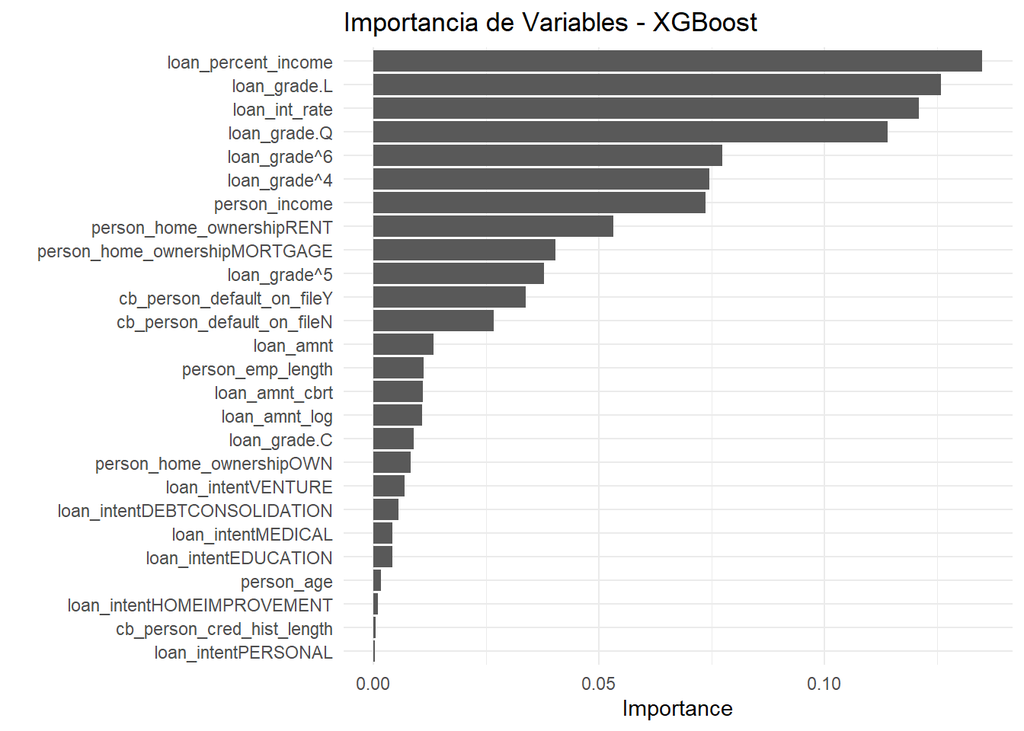

```r
vip::vip(extract_fit_engine(boost_fit), num_features = max(20, nrow(importance_matrix))) +
  ggtitle("Importancia de Variables - XGBoost") +
  theme_minimal()
```

## Modelo SVM.

Empezamos fijando la semilla para reproducibilidad y definimos la validación cruzada con 5 particiones y 1 repetición.

```r
set.seed(123)
loan_cvrp <- rsample::vfold_cv(loan_train, v = 5,  repeats = 1)
```

Definimos el modelo SVM lineal con un parámetro cost de 5, creamos el workflow uniendo la receta de preprocesamiento y el modelo de SVM. Finalmente definimos el conjunto de métricas.

```r
svmlin_loan_model <- svm_linear(cost = 5) |>
  set_engine("kernlab")  |>
  set_mode("classification")
svmlin_wf <- workflow() |>
  add_recipe(loan_recipe) |>
  add_model(svmlin_loan_model)
ctrl <- control_resamples(event_level = "second")
```

```r
perf_metr_loan <- metric_set(accuracy, detection_prevalence, sens, precision, f_meas, spec, roc_auc)
asses1_loan_cvrp <- fit_resamples(svmlin_wf,
                                  resamples = loan_cvrp,
                                  metrics = perf_metr_loan,
                                  control = ctrl)
collect_metrics(asses1_loan_cvrp)
```

[output not shown]

- **Modelo Radial**

Definimos el modelo SVM con kernel radial y creamos el workflow con la receta de preprocesamiento y el modelo SVM radial.

```r
svmrb_model <- svm_rbf(cost = 1, rbf_sigma = 0.01) |>
  set_engine("kernlab")  |>
  set_mode("classification")
svmrb_wf <- workflow() |>
  add_recipe(loan_recipe) |>
  add_model(svmrb_model)
```

Evaluamos el modelo SVM radial usando validación cruzada. Y mostramos las métricas de evaluación.

```r
asses3_loan_cvrp <- fit_resamples(svmrb_wf,
                                  resamples = loan_cvrp,
                                  metrics = perf_metr_loan,
                                  control = ctrl)
collect_metrics(asses3_loan_cvrp)
```

[output not shown]

Definimos el modelo SVM con kernel radial, tuneando ‘cost’ y ‘rbf_sigma’. Y creamos el workflow.

```r
# Generamos grid
svmrb_model_tune <- svm_rbf(cost = tune(), rbf_sigma = tune()) |>
  set_engine("kernlab")  |>
  set_mode("classification")
```

```r
svmrb_wf_tune <- workflow() |>
  add_recipe(loan_recipe) |>
  add_model(svmrb_model_tune)
```

Extraemos los hiperparámetros, generamos el grid y lo mostramos.

```r
svmrb_wf_tune_param  <- extract_parameter_set_dials(svmrb_wf_tune)
grid_svmrb_wf_tune <- expand.grid(cost = cost() |>
                                    value_seq(n = 5, original = TRUE),
                                  rbf_sigma = rbf_sigma() |>
                                    value_seq(n = 5, original = TRUE))

cost()
rbf_sigma()
grid_svmrb_wf_tune
```

[output not shown]

Configuramos la paralelización y utilizamos todos los núcleos menos 2.

```r
cl <- makePSOCKcluster(parallel::detectCores() - 2)
registerDoParallel(cl)
```

Configuramos el control del proceso de tuneado. Y ejecutamos la sintonización de hiperparámetros mediante validación cruzada.

```r
ctrl_tune <- control_grid(save_pred = TRUE, verbose = TRUE)

# Ejecutar tuning con validación cruzada
svmrb_tune_results <- tune_grid(
  svmrb_wf_tune,
  resamples = loan_cvrp,
  grid = grid_svmrb_wf_tune,
  metrics = perf_metr_loan,
  control = ctrl_tune
)
```

Detenemos la paralelización y mostramos las métricas.

```r
stopCluster(cl)

svmrb_tune_results |>
  collect_metrics()
```

```
# A tibble: 175 × 8
       cost    rbf_sigma .metric          .estimator  mean     n std_err .config
      <dbl>        <dbl> <chr>            <chr>      <dbl> <int>   <dbl> <chr>
 1 0.000977 0.0000000001 accuracy         binary     0.783     5 0.00244 Prepro…
 2 0.000977 0.0000000001 detection_preva… binary     1         5 0       Prepro…
 3 0.000977 0.0000000001 f_meas           binary     0.878     5 0.00154 Prepro…
 4 0.000977 0.0000000001 precision        binary     0.783     5 0.00244 Prepro…
 5 0.000977 0.0000000001 roc_auc          binary     0.729     5 0.0549  Prepro…
 6 0.000977 0.0000000001 sens             binary     1         5 0       Prepro…
 7 0.000977 0.0000000001 spec             binary     0         5 0       Prepro…
 8 0.0131   0.0000000001 accuracy         binary     0.783     5 0.00244 Prepro…
 9 0.0131   0.0000000001 detection_preva… binary     1         5 0       Prepro…
10 0.0131   0.0000000001 f_meas           binary     0.878     5 0.00154 Prepro…
# ℹ 165 more rows
```

Seleccionamos la mejor combinación de hiperparámetros basándonos en la métrica roc_auc, filtramos las métricas obtenidas para la combinación óptima de cost y rbf_sigma. Finalmente mostramos las métricas asociadas a los mejores hiperparámetros.

```r
best_params_svm <- select_best(svmrb_tune_results, metric = "roc_auc")
print(best_params_svm)
```

```
# A tibble: 1 × 3
   cost rbf_sigma .config
  <dbl>     <dbl> <chr>
1    32   0.00316 Preprocessor1_Model20
```

```r
# Filtro métricas
best_svm_metrics <- svmrb_tune_results |>
  collect_metrics() |>
  filter(cost == best_params_svm$cost, rbf_sigma == best_params_svm$rbf_sigma)

# Resultados
print(best_svm_metrics)
```

```
# A tibble: 7 × 8
   cost rbf_sigma .metric              .estimator  mean     n  std_err .config
  <dbl>     <dbl> <chr>                <chr>      <dbl> <int>    <dbl> <chr>
1    32   0.00316 accuracy             binary     0.896     5 0.00264  Preproce…
2    32   0.00316 detection_prevalence binary     0.846     5 0.000926 Preproce…
3    32   0.00316 f_meas               binary     0.936     5 0.00170  Preproce…
4    32   0.00316 precision            binary     0.901     5 0.00273  Preproce…
5    32   0.00316 roc_auc              binary     0.901     5 0.00298  Preproce…
6    32   0.00316 sens                 binary     0.973     5 0.00163  Preproce…
7    32   0.00316 spec                 binary     0.615     5 0.00681  Preproce…
```

Definimos los modelo con mejores hiperparámetros y los integramos al workflow.

```r
final_svm_model <- svm_rbf(cost = best_params_svm$cost,
                           rbf_sigma = best_params_svm$rbf_sigma) |>
  set_engine("kernlab") |>
  set_mode("classification")

# Workflow con el mejor modelo
final_svm_wf <- workflow() |>
  add_recipe(loan_recipe) |>
  add_model(final_svm_model)
```

Entrenamos el modelo con los datos de entrenamiento.

```r
final_svm_fit <- final_svm_wf |>
  fit(data = loan_train)
```

Hacemos predicciones con el modelo ajustado sobre el conjunto de prueba.

```r
svm_predictions <- final_svm_fit |>
  predict(new_data = loan_test) |>
  bind_cols(loan_test)
```

Convertimos las predicciones de 0/1 a factores “No” y “Yes”

```r
svm_predictions <- svm_predictions |>
  mutate(
    .pred_class = ifelse(.pred_class == 1, "Yes", "No"),  # Transformar valores
    .pred_class = factor(.pred_class, levels = c("No", "Yes"))  # Convertir a factor con niveles correctos
  )
```

Convertimos la variable loan_status en un factor con los mismos niveles que las predicciones, y verificamos que los niveles de ambas variables sean los mismos .

```r
svm_predictions <- svm_predictions |>
  mutate(
    loan_status = factor(loan_status, levels = c("No", "Yes"))
  )
print(levels(svm_predictions$.pred_class))
```

```
[1] "No"  "Yes"
```

```r
print(levels(svm_predictions$loan_status))
```

```
[1] "No"  "Yes"
```

Definimos el conjunto de métricas para evaluar el rendimiento del modelo, calculamos estas métricas y mostramos los resultados finales.

```r
# Definir las métricas que queremos calcular
metricas_completas <- metric_set(accuracy, sens, spec, precision, f_meas, detection_prevalence)

# Calcular todas las métricas usando la probabilidad de "Yes"
final_metrics <- svm_predictions |>
  metricas_completas(truth = loan_status, estimate = .pred_class,
                     prob = .pred_Yes)  # <-- Aquí usamos la probabilidad

# Mostrar métricas finales
print(final_metrics)
```

```
# A tibble: 6 × 3
  .metric              .estimator .estimate
  <chr>                <chr>          <dbl>
1 accuracy             binary         0.894
2 sens                 binary         0.973
3 spec                 binary         0.614
4 precision            binary         0.899
5 f_meas               binary         0.934
6 detection_prevalence binary         0.843
```

La accuracy baja un 4% con respecto al boosting.

Sin embargo, en este modelo se ve perjudicada la especificidad a 0,61.